# Standard pre-processing workflow

## Determine the ‘dimensionality’ of the dataset

To overcome the extensive technical noise in any single feature for scRNA-seq data, Seurat clusters cells based on their PCA scores, with each PC essentially representing a ‘metafeature’ that combines information across a correlated feature set. The top principal components therefore represent a robust compression of the dataset.

```r
# original unmodified data still resides in the 'RNA' assay
# Set the default assay for the Seurat object 'integrated_seuratfish' to "integrated"
DefaultAssay(integrated_seuratfish) <- "integrated"

# Scale the data in the 'integrated' assay of 'integrated_seuratfish'
integrated_seuratfish <- ScaleData(integrated_seuratfish, verbose = FALSE)

# Run Principal Component Analysis (PCA) on the scaled data
# 'npcs = 50' specifies the number of principal components to compute
# 'verbose = FALSE' suppresses verbose output during PCA
integrated_seuratfish <- RunPCA(integrated_seuratfish, npcs = 50, verbose = FALSE)
```

The Elbow plot ranks of principle components based on the percentage of variance explained by each one

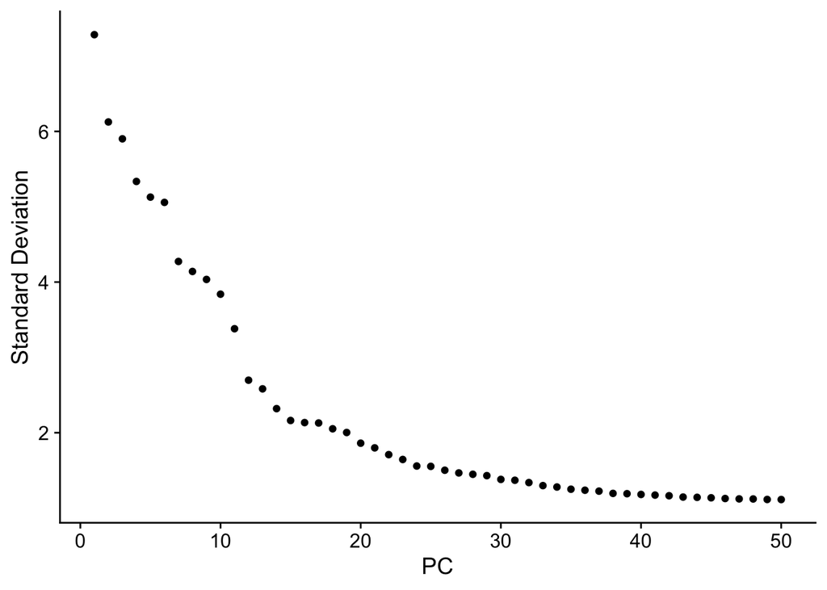

```r
ElbowPlot(integrated_seuratfish, ndims = 50)
```

There is no clear elbow on this plot, so several dimensions were tried in downnstream UMAP and DEG analysis before settling on 45 dimensions.

##Dimension reduction and clustering the cells

```r
# RunUMAP: Runs UMAP (Uniform Manifold Approximation and Projection) to reduce the dimensionality of the dataset
# 'reduction = "pca"': Uses principal components obtained from PCA (Principal Component Analysis)
# 'dims = 1:45': Specifies the dimensions to be used for UMAP (in this case, the first 45 principal components)
integrated_seuratfish <- RunUMAP(integrated_seuratfish, reduction = "pca", dims = 1:45)
# FindNeighbors: Identifies neighboring cells based on the reduced dimensions (e.g., PCA)
# 'reduction = "pca"': Specifies the reduction method to use (PCA in this case)
# 'dims = 1:45': Specifies the dimensions to be used for finding neighbors
integrated_seuratfish <- FindNeighbors(integrated_seuratfish, reduction = "pca", dims = 1:45)
# FindClusters: Performs clustering on the dataset based on the identified neighbors
# 'resolution controls the granularity of the clustering; smaller values result in more clusters
integrated_seuratfish <- FindClusters(integrated_seuratfish, resolution = 0.24)
```

```
## Modularity Optimizer version 1.3.0 by Ludo Waltman and Nees Jan van Eck
##
## Number of nodes: 55936
## Number of edges: 3370282
##
## Running Louvain algorithm...
## Maximum modularity in 10 random starts: 0.9652
## Number of communities: 19
## Elapsed time: 11 seconds
```

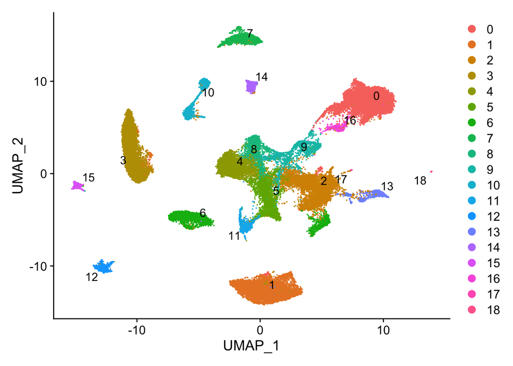

```r
# Visualization of cell clusters
DimPlot(integrated_seuratfish, reduction = "umap", label = TRUE, repel = TRUE)
```

## Making a list of differentially expressed genes (DEGs) per cluster in order to identify cell type

```r
#This command identifies the DEGs in cluster 0 in comparison to all other clusters
cluster0.markers <- FindMarkers(integrated_seuratfish, ident.1 = 0, logfc.threshold = 0.25, test.use = "roc", only.pos = TRUE)

#Print the top 20 most significantly DEGs
top10_genes <- head(cluster0.markers, 10)
print(top10_genes)
```

```
##              myAUC avg_diff power avg_log2FC pct.1 pct.2
## LOC115546516 0.963 2.924214 0.926   4.218749 0.983 0.690
## LOC115543484 0.948 2.746952 0.896   3.963013 0.964 0.664
## LOC115529499 0.943 2.730687 0.886   3.939548 0.955 0.577
## LOC115554304 0.940 2.574391 0.880   3.714061 0.964 0.632
## swap70       0.936 2.599226 0.872   3.749891 0.954 0.649
## LOC115542751 0.933 2.071343 0.866   2.988317 0.972 0.653
## cd79a        0.920 2.368975 0.840   3.417708 0.921 0.545
## cd79b        0.919 2.153236 0.838   3.106463 0.929 0.627
## LOC115559315 0.919 1.991038 0.838   2.872460 0.930 0.607
## LOC115531259 0.913 1.824016 0.826   2.631499 0.914 0.604
```

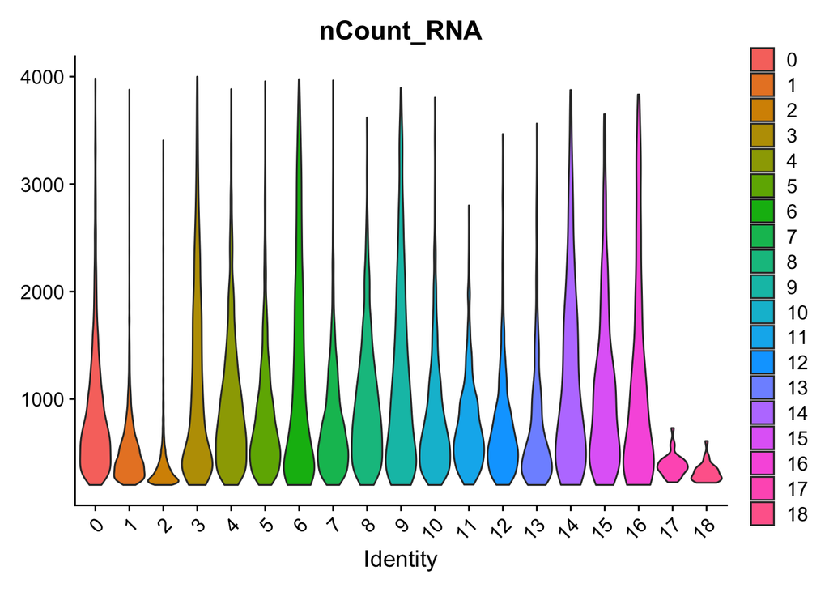

```r
# This violin plot shows the average number of transcripts expressed per cell within each cluster
VlnPlot(integrated_seuratfish, features = c("nCount_RNA"), group.by = "seurat_clusters", pt.size = 0)
```

```r
# Filter out cells in cluster 2
cleaned_seuratfish <- subset(integrated_seuratfish, subset = seurat_clusters != 2)
```